# Data Cleaning and Descriptive Checks

Author

Anonymous

**ImportantTLDR**

We perform data cleaning in this document. We exclude participants who:

- … have eye-to-screen distance < 20 cm
- has Pearson correlation < 0.5 to the actual answer

# Set up

Read in data:

```r
# read in scale
exp1_x <- make_va_scale(data_min = -5, data_max = 5, px_min = 50, px_max = 585)
exp1_y <- make_va_scale(data_min = 0, data_max = 1, px_min = 410, px_max = 15)

# read in data from the three runs
df1 <- read.csv(here::here("data", "part1", "pilot-01.csv")) %>% as_tibble(.)
df2 <- read.csv(here::here("data", "part1", "pilot-02.csv")) %>% as_tibble(.)
df3 <- read.csv(here::here("data", "part1", "pilot-03.csv")) %>% as_tibble(.)

# combine data from the three runs
combined_df <- bind_rows(df1, df2, df3)

df <- combined_df %>%
  filter(status == "completed") %>%
  mutate(rsp_time = as.numeric(cleanedDuration) / 1000) %>% # seconds
  select(participantId, trialId, responseId, answer, rsp_time, status)

task_df <- df %>%
  filter(str_detect(trialId, "task")) %>%
  mutate(answer = as.numeric(answer)) %>%
  pivot_wider(
    names_from = responseId,
    values_from = answer,
    names_repair = "universal"
  ) %>%
  separate_wider_delim(
    trialId,
    delim = "_",
    names = c("task", "type", "id")
  ) %>%
  filter(type != "train") %>%
  select(-type) %>%
  rename(
    data.select.x = location.x,
    data.select.y = location.y,
    pixel.select.x = pixel.x,
    pixel.select.y = pixel.y
  )

# initialize empty list of participants to be excluded from analysis
exclude_participants <- c()
```

Some participants did not answer the calibration tasks truthfully. Therefore, we need to reverse engineer the pixel location of `squarePos` to verify if participants actually put in the correct effort into the calibration tasks.

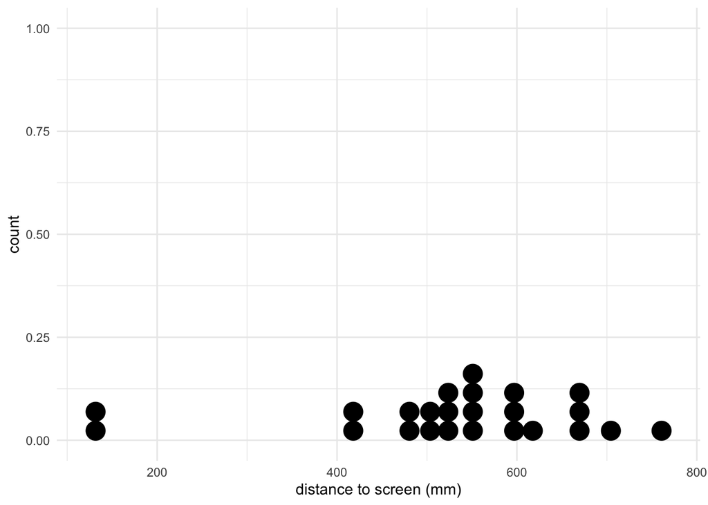

```r
p <- df %>%
  filter(status == "completed") %>%
  select(participantId, trialId, responseId, answer) %>%
  filter(grepl("calibration", trialId))

ball_positions <- df %>%
  filter(status == "completed") %>%
  filter(grepl("calibration", trialId)) %>%
  select(participantId, responseId, answer) %>%
  pivot_wider(names_from = responseId, values_from = answer) %>%
  # filter(!is.na(`square-position`)) %>%
  mutate(`ball-positions` = gsub("\\[|\\]", "", `ball-positions`)) %>%
  mutate(split_answer = str_split(`ball-positions`, ",")) %>%
  mutate(numeric_vectors = map(split_answer, ~ as.numeric(.x))) %>%
  unnest(split_answer) %>%
  mutate(split_answer = as.numeric(split_answer)) %>%
  group_by(participantId) %>%
  summarise(
    avg.ball.pos = sum(split_answer) / 5,
    min.ball.pos = min(split_answer),
    max.ball.pos = max(split_answer),
    true_ball_pos = (avg.ball.pos * 5 - min.ball.pos - max.ball.pos) / 3
  )

calibrations <- p %>%
  filter(grepl("pixelsPerMM|dist-calibration-MM", responseId)) %>%
  select(-trialId) %>%
  mutate(answer = as.numeric(answer)) %>%
  pivot_wider(names_from = responseId, values_from = answer) %>%
  rename(pixelToMM = pixelsPerMM, dist_to_screen = `dist-calibration-MM`)

participants <- calibrations %>%
  right_join(ball_positions, by = join_by(participantId)) %>%
  mutate(
    phy = dist_to_screen * tan(13.5 * pi / 180),
    px = phy * pixelToMM,
    square_pos = round(px + avg.ball.pos)
  ) %>%
  mutate(
    ball.square.dist = (square_pos - true_ball_pos) / pixelToMM,
    d = ball.square.dist / tan(13.5 * pi / 180)
  ) %>%
  select(participantId, pixelToMM, d) %>%
  rename(dist_to_screen = d)

# plot distance to screen distribution
participants %>%
  ggplot(aes(x = dist_to_screen)) +
  geom_dotplot() +
  labs(x = "distance to screen (mm)")
```

From the above histogram, two participants have `dist_to_screen` less than 200 mm. This indicates that they did not press the space bar in the calibration tasks as instructed, thus we do not include these participants in our analysis.

```r
# add these participants to filter out
exclude_participants <- c(
  participants %>% filter(dist_to_screen <= 200) %>% pull(participantId),
  exclude_participants
)
```

```r
participants %>% filter(dist_to_screen > 200) -> participants
```

# Going through each task …

In the following we will go through each task, and determine the participants we exclude from our analysis. Note that we index each tasks with names such as “task 1” and “task 2”, etc., because that’s how we named each task in the configuration file, for easier indexing and referencing.

## Task 1 – `BisectArea` – split area into equal halves

Load data:

```r
task1_df <- task_df %>%
  filter(task == "task1") %>%
  select(-slider.x, -slider.y) %>%
  right_join(participants, by = join_by(participantId)) %>%
  mutate(
    data.select.left_area = psgt(
      data.select.x,
      param.mu,
      param.sigma,
      param.lambda,
      param.p,
      param.q,
      mean.cent = FALSE
    ),
    data.ans.x = qsgt(
      0.5,
      param.mu,
      param.sigma,
      param.lambda,
      param.p,
      param.q,
      mean.cent = FALSE
    )
  ) %>%
  mutate(
    va.resp.x = exp1_x$data_to_va(data.select.x, dist_to_screen, pixelToMM),
    va.med.x = exp1_x$data_to_va(data.ans.x, dist_to_screen, pixelToMM),
    va.mod.x = exp1_x$data_to_va(param.mu, dist_to_screen, pixelToMM)
  )
```

Calculate correlation:

```r
task1_corr <- task1_df %>%
  group_by(participantId) %>%
  summarise(correlation.x = cor(data.select.x, data.ans.x)) %>%
  mutate(
    mean = mean(correlation.x),
    sd = sd(correlation.x),
    lb = mean - 2 * sd,
    ub = mean + 2 * sd
  )

task1_corr %>%
  filter(correlation.x < 0.5)
```

| participantId | correlation.x | mean | sd | lb | ub |
| --- | --- | --- | --- | --- | --- |
| 67ea39f872546624b6b520bf | -0.02461424 | 0.8723251 | 0.2634591 | 0.3454069 | 1.399243 |
| 67f44a0314ad081a761de62c | 0.23175049 | 0.8723251 | 0.2634591 | 0.3454069 | 1.399243 |

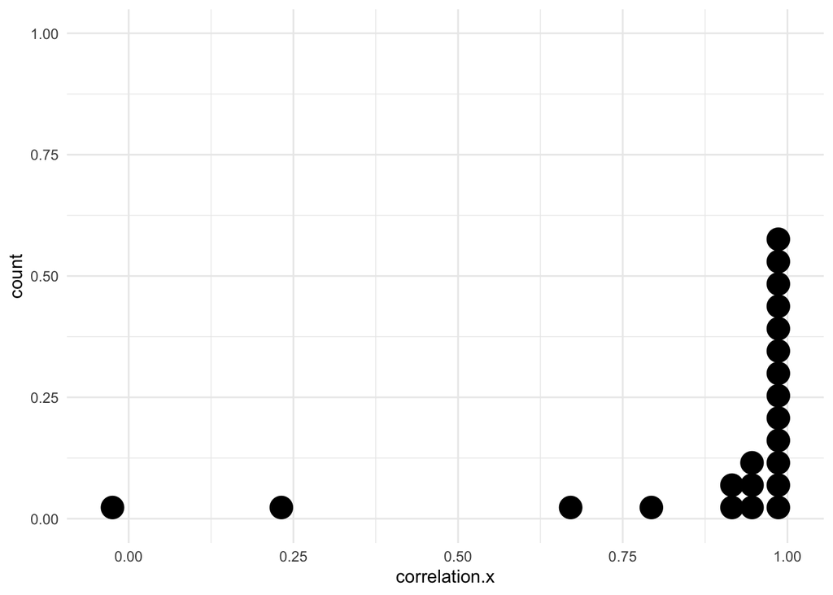

```r
task1_corr %>%
  ggplot(aes(x = correlation.x)) +
  geom_dotplot()
```

Given that most participants have correlation > 0.5, we filter out participant whose selection’s correlation to the actual answer has correlation < 0.5.

```r
exclude_participants <- c(
  task1_corr %>% filter(correlation.x < 0.5) %>% pull(participantId),
  exclude_participants
)

exclude_participants
```

```
[1] "67ea39f872546624b6b520bf" "67f44a0314ad081a761de62c"
[3] "6679e88eb948e8a4b08a39fb" "67eb99ebe23a2e1ce36ce110"
```

**NoteMore in-depth examination**

Let’s also examine the two participants who have correlation < 0.5 for task 1, by plotting the actual answer (in red) and the participants’ selection (in black):

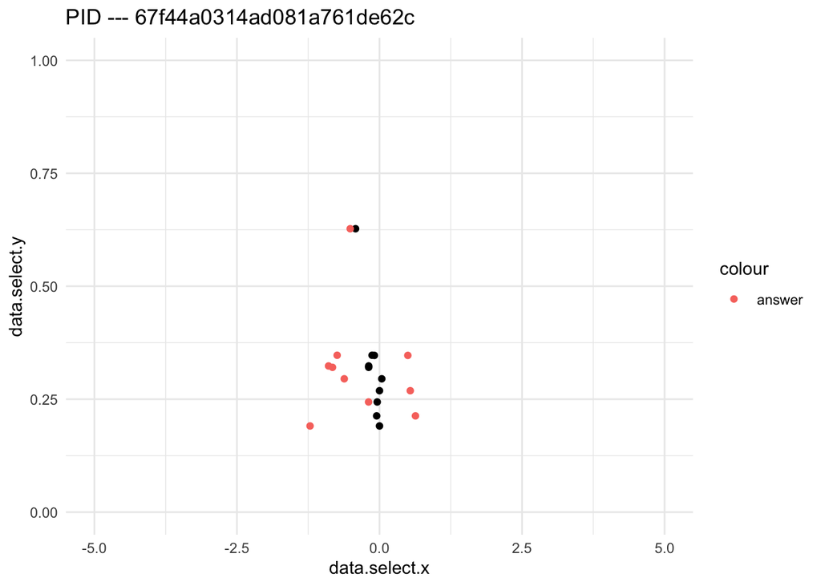

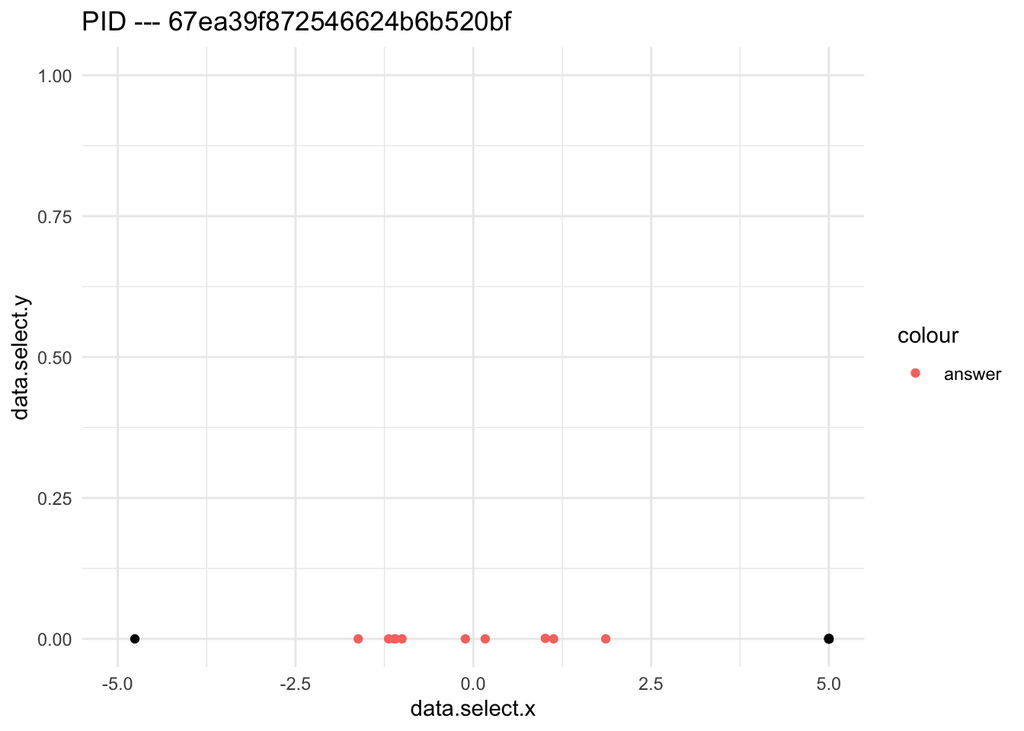

```r
task1_df %>%
  filter(participantId == "67f44a0314ad081a761de62c") %>%
  ggplot(aes(x = data.select.x, y = data.select.y)) +
  geom_point() +
  xlim(-5, 5) +
  ylim(0, 1) +
  geom_point(
    data = filter(task1_df, participantId == "67f44a0314ad081a761de62c"),
    aes(x = data.ans.x, color = "answer")
  ) +
  labs(title = "PID --- 67f44a0314ad081a761de62c")
task1_df %>%
  filter(participantId == "67ea39f872546624b6b520bf") %>%
  ggplot(aes(x = data.select.x, y = data.select.y)) +
  geom_point() +
  xlim(-5, 5) +
  ylim(0, 1) +
  geom_point(
    data = filter(task1_df, participantId == "67ea39f872546624b6b520bf"),
    aes(x = data.ans.x, color = "answer")
  ) +
  labs(title = "PID --- 67ea39f872546624b6b520bf")
```

This participant is selecting -5 or 5 all the time. Clearly demonstrated low effort. We exclude their answers from the final analysis.

## Task 2 – `HighestPoint` – Find highest point on curve

First we get the data:

```r
task2_df <- task_df %>%
  filter(task == "task2") %>%
  select(-slider.x, -slider.y) %>%
  mutate(
    data.ans.x = param.mu,
    data.ans.y = dsgt(
      param.mu,
      param.mu,
      param.sigma,
      param.lambda,
      param.p,
      param.q,
      mean.cent = FALSE
    ),
    # this is the gradient of the left of the highest point
    data.left.grad = numDeriv::grad(
      dsgt,
      param.mu - 1,
      mu = param.mu,
      sigma = param.sigma,
      lambda = param.lambda,
      p = param.p,
      q = param.q,
      mean.cent = FALSE
    ),
    data.right.grad = numDeriv::grad(
      dsgt,
      param.mu + 1,
      mu = param.mu,
      sigma = param.sigma,
      lambda = param.lambda,
      p = param.p,
      q = param.q,
      mean.cent = FALSE
    ),
  ) %>%
  right_join(participants, by = join_by(participantId)) %>%
  # calculate things related to participants' selection
  mutate(
    va.resp.x = exp1_x$px_to_va(pixel.select.x, dist_to_screen, pixelToMM),
    va.resp.y = exp1_y$px_to_va(pixel.select.y, dist_to_screen, pixelToMM),
    va.ans.x = exp1_x$data_to_va(data.ans.x, dist_to_screen, pixelToMM),
    va.ans.y = exp1_y$data_to_va(data.ans.y, dist_to_screen, pixelToMM),
  ) %>%
  mutate(flat = (abs(data.left.grad) + abs(data.right.grad)) / 2)
```

Calculate correlation[^1]:

<sup>1</sup> similar to what we did for Task 1, exclude those who have correlation to the true answer < 0.5

```r
task2_corr <- task2_df %>%
  group_by(participantId) %>%
  summarise(
    correlation.y = cor(data.select.y, data.ans.y),
    correlation.x = cor(data.select.x, data.ans.x)
  ) %>%
  filter(correlation.y < 0.5 | correlation.x < 0.5)

task2_corr
```

| participantId | correlation.y | correlation.x |
| --- | --- | --- |
| 67ea39f872546624b6b520bf | -0.4512904 | -0.09859427 |
| 67eedf7be13ffb77c677d4dd | 0.9935061 | 0.48743290 |

```r
exclude_participants <- c(
  exclude_participants,
  task2_corr %>% pull(participantId)
)

exclude_participants
```

```
[1] "67ea39f872546624b6b520bf" "67f44a0314ad081a761de62c"
[3] "6679e88eb948e8a4b08a39fb" "67eb99ebe23a2e1ce36ce110"
[5] "67ea39f872546624b6b520bf" "67eedf7be13ffb77c677d4dd"
```

**NoteFurther examination**

Examine particular participants:

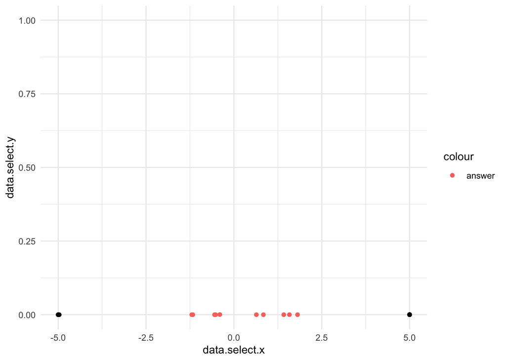

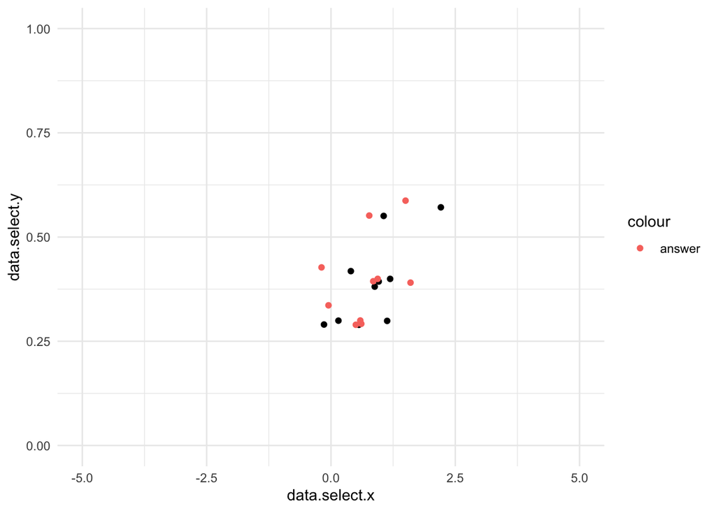

```r
task2_df %>%
  filter(participantId == "67ea39f872546624b6b520bf") %>%
  ggplot(aes(x = data.select.x, y = data.select.y)) +
  geom_point() +
  xlim(-5, 5) +
  ylim(0, 1) +
  geom_point(
    data = filter(task2_df, participantId == "67ea39f872546624b6b520bf"),
    aes(x = data.ans.x, color = "answer")
  )
task2_df %>%
  filter(participantId == "67eedf7be13ffb77c677d4dd") %>%
  ggplot(aes(x = data.select.x, y = data.select.y)) +
  geom_point() +
  xlim(-5, 5) +
  ylim(0, 1) +
  geom_point(
    data = filter(task2_df, participantId == "67eedf7be13ffb77c677d4dd"),
    aes(x = data.ans.x, y = data.ans.y, color = "answer")
  )
```

## Task 3 – `ProjectToCurve` – find point on curve where `y == 0.5`

First we get the data:

```r
task3_df <- task_df %>%
  filter(task == "task3") %>%
  select(-slider.x, -slider.y) %>%
  right_join(participants, by = join_by(participantId)) %>%
  mutate(
    data.ans.y = 0.5,
    data.ans.x = qsgt(
      0.5,
      param.mu,
      param.sigma,
      param.lambda,
      param.p,
      param.q,
      mean.cent = FALSE
    )
  ) %>%
  mutate(
    va.resp.x = exp1_x$data_to_va(data.select.x, dist_to_screen, pixelToMM),
    va.resp.y = exp1_y$data_to_va(data.select.y, dist_to_screen, pixelToMM),
    va.ans.x = exp1_x$data_to_va(data.ans.x, dist_to_screen, pixelToMM),
    va.ans.y = exp1_y$data_to_va(data.ans.y, dist_to_screen, pixelToMM)
  )
```

Calculation correlation and exclude participants:

```r
# note that can't calculat correlation on y because the standard deviation is 0.
# so we use x as an approximation

task3_corr <- task3_df %>%
  group_by(participantId) %>%
  summarise(
    correlation.x = suppressWarnings(cor(data.select.x, data.ans.x))
  ) %>%
  filter(is.na(correlation.x) | correlation.x < 0.5)

task3_corr
```

| participantId | correlation.x |
| --- | --- |
| 67ea39f872546624b6b520bf | NA |
| 67ee9fb880b10fe380af1803 | -0.1844966 |
| 67fd4f955123c6d79ae66a3a | NA |

```r
exclude_participants <- c(exclude_participants, pull(task3_corr, participantId))
exclude_participants
```

```
[1] "67ea39f872546624b6b520bf" "67f44a0314ad081a761de62c"
[3] "6679e88eb948e8a4b08a39fb" "67eb99ebe23a2e1ce36ce110"
[5] "67ea39f872546624b6b520bf" "67eedf7be13ffb77c677d4dd"
[7] "67ea39f872546624b6b520bf" "67ee9fb880b10fe380af1803"
[9] "67fd4f955123c6d79ae66a3a"
```

**NoteFurther examine**

Examine particular participants:

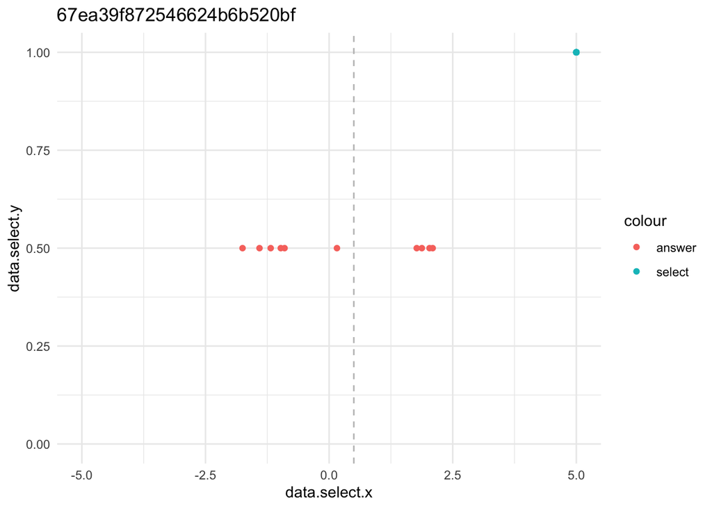

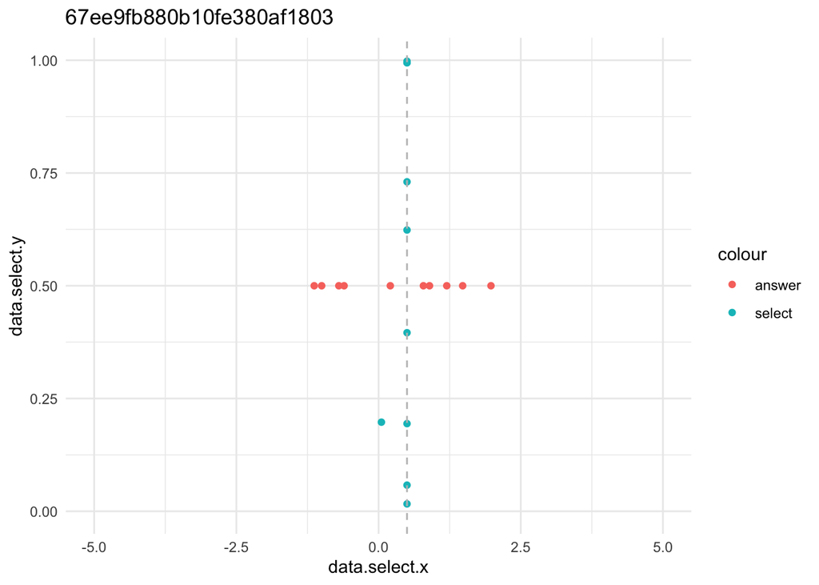

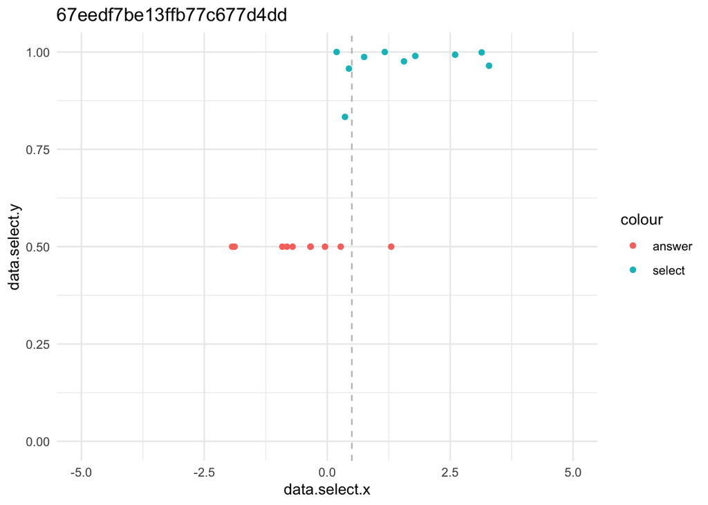

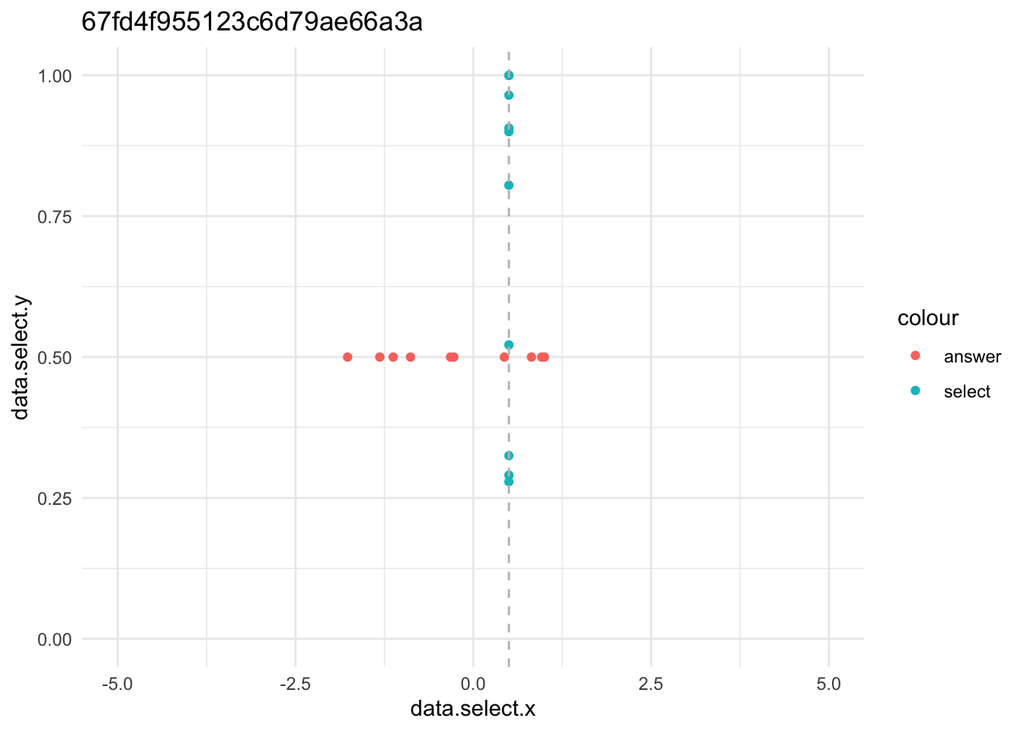

```r
task3_plot <- function(pid) {
  task3_df %>%
    filter(participantId == pid) %>%
    ggplot() +
    geom_point(aes(x = data.select.x, y = data.select.y, color = "select")) +
    geom_point(aes(x = data.ans.x, y = 0.5, color = "answer")) +
    ylim(0, 1) +
    xlim(-5, 5) +
    geom_vline(xintercept = 0.5, linetype = "dashed", color = "gray") +
    labs(title = pid)
}

task3_plot("67ea39f872546624b6b520bf")
task3_plot("67ee9fb880b10fe380af1803")
task3_plot("67eedf7be13ffb77c677d4dd")
task3_plot("67fd4f955123c6d79ae66a3a")
```

## Task 4 – `MaxSlope` – find maximum slope

Define helper functions:

```r
# x: one unit in data maps to (585 - 50)/(5 - (-5)) in pixel
# y: one unit in data maps to (410 - 15)/(1 - 0) in pixel
data_to_screen_slope <- function(k) {
  return(k * 395 / 53.5)
}
data_to_va_slope <- function(data_x, data_y, dist, px_per_mm) {
  eps <- 1e-6
  s_y <- abs(
    exp1_y$data_to_va(data_y + eps, dist, px_per_mm) -
      exp1_y$data_to_va(data_y, dist, px_per_mm)
  ) /
    eps
  s_x <- (abs(
    exp1_x$data_to_va(data_x + eps, dist, px_per_mm) -
      exp1_x$data_to_va(data_x, dist, px_per_mm)
  ) /
    eps)
  return(s_y / s_x)
}
```

Get data:

```r
task4_df <- task_df %>%
  filter(task == "task4") %>%
  select(-slider.x, -slider.y) %>%
  right_join(participants, by = join_by(participantId)) %>%
  mutate(
    data.resp.slope = dsgt(
      data.select.x,
      param.mu,
      param.sigma,
      param.lambda,
      param.p,
      param.q,
      mean.cent = FALSE
    ),
    data.ans.slope = dsgt(
      param.mu,
      param.mu,
      param.sigma,
      param.lambda,
      param.p,
      param.q,
      mean.cent = FALSE
    ),
    data.ans.x = param.mu,
    data.ans.y = 0.5 *
      (psgt(
        data.ans.x + tolerance,
        param.mu,
        param.sigma,
        param.lambda,
        param.p,
        param.q,
        mean.cent = FALSE
      ) +
        psgt(
          data.ans.x - tolerance,
          param.mu,
          param.sigma,
          param.lambda,
          param.p,
          param.q,
          mean.cent = FALSE
        )),
    va.resp.slope = data.resp.slope *
      data_to_va_slope(
        data.select.x,
        data.select.y,
        dist_to_screen,
        pixelToMM
      ),
    va.ans.slope = data.ans.slope *
      data_to_va_slope(
        data.ans.x,
        data.ans.y,
        dist_to_screen,
        pixelToMM
      )
  )
```

Calculate correlation:

```r
task4_corr <- task4_df %>%
  group_by(participantId) %>%
  summarise(
    correlation = cor(va.resp.slope, va.ans.slope)
  ) %>%
  filter(correlation < 0.5)

task4_corr
```

| participantId | correlation |
| --- | --- |
| 67ea39f872546624b6b520bf | -0.1932029 |

```r
exclude_participants <- c(exclude_participants, pull(task4_corr, participantId))
exclude_participants
```

```
 [1] "67ea39f872546624b6b520bf" "67f44a0314ad081a761de62c"
 [3] "6679e88eb948e8a4b08a39fb" "67eb99ebe23a2e1ce36ce110"
 [5] "67ea39f872546624b6b520bf" "67eedf7be13ffb77c677d4dd"
 [7] "67ea39f872546624b6b520bf" "67ee9fb880b10fe380af1803"
 [9] "67fd4f955123c6d79ae66a3a" "67ea39f872546624b6b520bf"
```

## Task 5 – `ProjectToAxis` – Project from dot to axes

Get data:

```r
task5_df <- task_df %>%
  filter(task == "task5") %>%
  select(
    participantId,
    task,
    id,
    data.select.x,
    data.select.y,
    slider.x,
    slider.y
  ) %>%
  rename(
    data.ans.x = data.select.x,
    data.ans.y = data.select.y,
    data.resp.x = slider.x,
    data.resp.y = slider.y
  ) %>%
  right_join(participants, by = join_by(participantId)) %>%
  # convert from data space to visual angle space
  mutate(
    va.resp.x = exp1_x$data_to_va(data.resp.x, dist_to_screen, pixelToMM),
    va.resp.y = exp1_y$data_to_va(data.resp.y, dist_to_screen, pixelToMM),
    va.ans.x = exp1_x$data_to_va(data.ans.x, dist_to_screen, pixelToMM),
    va.ans.y = exp1_y$data_to_va(data.ans.y, dist_to_screen, pixelToMM),
  )
```

Check correlation:

```r
task5_corr <- task5_df %>%
  group_by(participantId) %>%
  summarise(
    correlation.x = cor(data.resp.x, data.ans.x),
    correlation.y = cor(data.resp.y, data.ans.y)
  ) %>%
  filter(correlation.x < 0.9 | correlation.y < 0.9)

task5_corr
```

| participantId | correlation.x | correlation.y |
| --- | --- | --- |
| 6443ebb84fc33e703937a6f9 | 0.99362807 | 0.18403431 |
| 67ea39f872546624b6b520bf | NA | 0.53280169 |
| 67eedf7be13ffb77c677d4dd | -0.08672003 | 0.07825885 |

```r
exclude_participants <- c(
  exclude_participants,
  task5_corr %>% pull(participantId)
)
```

**NoteFurther examination**

Examine specific participants:

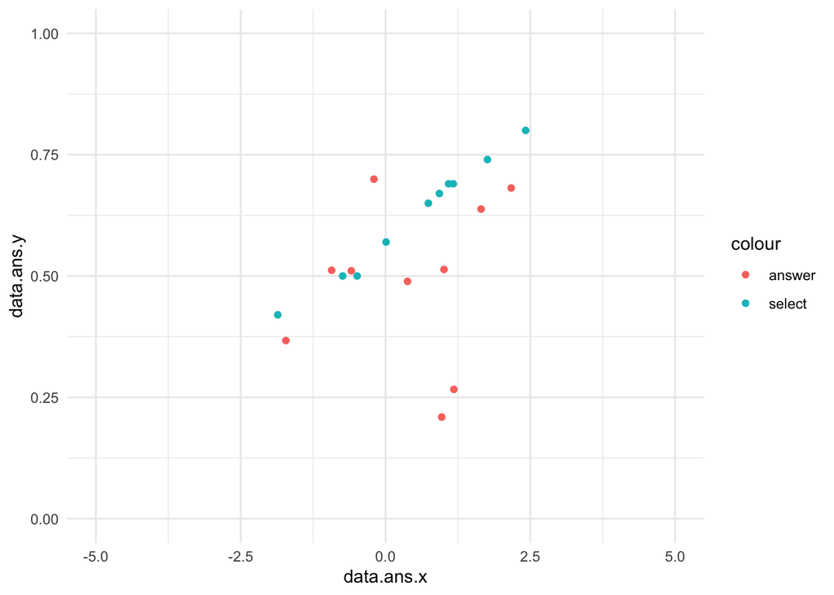

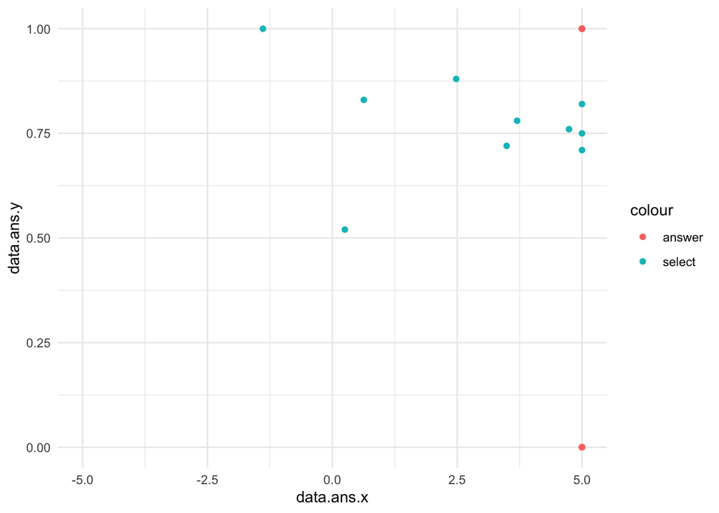

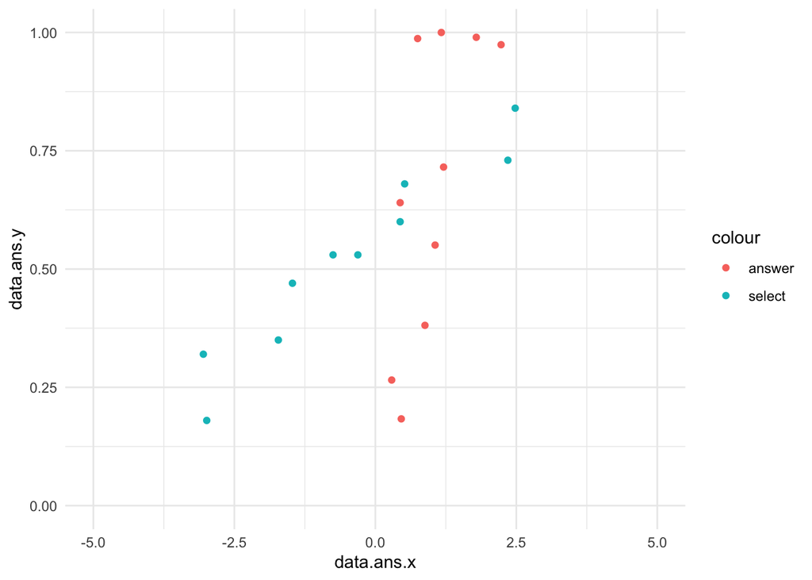

```r
task5_plot <- function(pid) {
  task5_df %>%
    filter(participantId == pid) %>%
    ggplot() +
    geom_point(aes(x = data.ans.x, y = data.ans.y, color = "answer")) +
    geom_point(aes(x = data.resp.x, y = data.resp.y, color = "select")) +
    xlim(-5, 5) +
    ylim(0, 1)
}

task5_plot("6443ebb84fc33e703937a6f9")
task5_plot("67ea39f872546624b6b520bf")
task5_plot("67eedf7be13ffb77c677d4dd")
```

# How long on average did people spend?

```r
df %>%
  filter(!participantId %in% exclude_participants) %>%
  filter(grepl("task", trialId)) %>%
  group_by(participantId, trialId, rsp_time) %>%
  summarise(.) %>%
  group_by(participantId) %>%
  summarise(sum_rsp = sum(rsp_time)) %>%
  pull(sum_rsp) %>%
  mean(.) /
  60
```

```
[1] 18.3977
```

# Calculate demographics related information

Per reviewer request, we also calculate demographics related information.

```r
# check gender
df %>%
  filter(!participantId %in% exclude_participants) %>%
  filter(responseId == "gender") %>%
  count(answer)
```

| answer | n |
| --- | --- |
| Female | 8 |
| Male | 8 |

```r
# check age
df %>%
  filter(!participantId %in% exclude_participants) %>%
  filter(responseId == "age") %>%
  mutate(answer = as.numeric(answer)) %>%
  pull(answer) -> age

min(age)
```

```
[1] 31
```

```r
max(age)
```

```
[1] 63
```

```r
mean(age)
```

```
[1] 43.5625
```

```r
sd(age)
```

```
[1] 9.688266
```

# Check if response had text on strategy

Per reviewer feedback let’s check if they said anything about the strategy they took.

```r
task_df %>% filter(!participantId %in% exclude_participants) -> task_df

combined_df %>%
  filter(!participantId %in% exclude_participants) %>%
  filter(responseId == "strategy") %>%
  select(answer)
```

| answer |
| --- |
| Just my sitting posture and sight. |
| Sometimes I used my left hand on the other line to line it up with the dot. |

[output cut: 6 more lines]

# Save the cleaned data

Count the number of times participants are excluded[^2]:

<sup>2</sup> Given that we have five tasks, the maximum number of times that a participant can be excluded is 5

```r
exclude_participants %>% as_tibble() %>% count(value)
```

| value | n |
| --- | --- |
| 6443ebb84fc33e703937a6f9 | 1 |
| 6679e88eb948e8a4b08a39fb | 1 |
| 67ea39f872546624b6b520bf | 5 |
| 67eb99ebe23a2e1ce36ce110 | 1 |
| 67ee9fb880b10fe380af1803 | 1 |
| 67eedf7be13ffb77c677d4dd | 2 |
| 67f44a0314ad081a761de62c | 1 |
| 67fd4f955123c6d79ae66a3a | 1 |

Save the cleaned files:

```r
saveRDS(task_df, file = here::here("data", "part1", "task.rds"))

participants %>%
  filter(!participantId %in% exclude_participants) %>%
  saveRDS(., here::here("data", "part1", "participants.rds"))
```